# Zadatak 4 - Izvješće o provedenoj analizi odabira projekata za IT odjel

Barbara Medica

12.1.2026.

## 1. Opći podatci:

1.1. **Naručitelj analize:** Direktor IT odjela

1.2. **Datum narudžbe analize:** 12.1.2026.

1.3. **Rok predaje analize:** 14.1.2026.

1.4. **Razlog i cilj analize:** Direktor ima budžet od 1.5 milijuna eura i tim od 20 senior developera za sljedeću godinu. Treba odlučiti koje projekte pokrenuti da bi postigao najbolje rezultate. Problem je što ne može raditi sve projekte odjednom zbog ograničenja u novcu i broju ljudi, a neki projekti se međusobno isključuju ili ovise jedni o drugima. Potrebno je balansirati više ciljeva: postići dobar povrat investicije (ROI), držati se unutar budžeta i maksimalno iskoristiti dostupni tim.

## 2. Opis postupka provedbe analize

### 2.1. Osnovni ciljevi i zadatci analize

Glavni cilj je odabrati projekte koji će najbolje zadovoljiti više ciljeva tvrtke s obzirom na dostupan budžet i ljude. Konkretno, potrebno je:

- Napraviti matematički model problema s više ciljeva
- Uzeti u obzir sve resurse i pravila koja postoje između projekata
- Definirati prioritete među ciljevima
- Izračunati najbolju kombinaciju projekata koja balansira sve ciljeve

### 2.2. Kriteriji evaluacije alternativa

Projekte biram prema više kriterija koji imaju različite prioritete:

- **Cilj 1 (najvažniji):** Postići ROI od najmanje 200 bodova vrijednosti
- **Cilj 2:** Držati se budžeta od 1.5 milijuna € (ne prekoračiti)
- **Cilj 3:** Maksimalno iskoristiti tim (barem 18 od 20 senior developera)
- **Tehnička pravila** - neki projekti se ne mogu raditi zajedno, neki ovise jedni o drugima

### 2.3. Koraci u provođenju analize

Analizu radim ovako:

1. Prvo definiram što su varijable odluke (koji projekt da ili ne)
2. Postavljam više ciljeva i njihove prioritete
3. Uvođenje varijabli odstupanja za mjerenje koliko smo blizu ili daleko od svakog cilja
4. Zapišem sve ciljeve i ograničenja matematički
5. Koristim R i paket za optimizaciju da riješim problem prioritet po prioritet
6. Tumačim što dobiveno rješenje znači u praksi i koje kompromise sam napravila

### 2.4. Korištene metode

Koristim **prioritetno ciljno programiranje** jer je problem takav da imam više ciljeva koji su djelomično konfliktni (npr. viši ROI znači veće troškove). Ova metoda omogućava: - Definiranje više ciljeva s različitim prioritetima - Mjerenje odstupanja od svakog cilja - Pronalaženje kompromisnog rješenja koje prvo zadovoljava najvažnije ciljeve - Donošenje binarne odluke za svaki projekt (da ili ne)

Koristila sam je R programski jezik s paketom lpSolve.

## 3. Rezultati

### 3.1. Struktura problema

**Varijable odluke:**

Za svaki projekt $i$ (gdje je $i = 1, 2, 3, 4, 5$) imam varijablu $x_i$ koja može biti: - $x_i = 1$ ako radim projekt - $x_i = 0$ ako ne radim projekt

**Varijable odstupanja:**

Za svaki cilj $j$ uvedene su dvije varijable odstupanja: - $d_j^+$ - pozitivno odstupanje (koliko smo iznad cilja) - $d_j^-$ - negativno odstupanje (koliko smo ispod cilja)

Vrijedi da samo jedna od njih može biti veća od nule u optimalnom rješenju.

**Ciljevi s odstupanjima:**

1. **Cilj 1 - ROI:** Postići najmanje 200 bodova
   $$90x_1 + 60x_2 + 50x_3 + 70x_4 + 30x_5 + d_1^- -
   d_1^+ = 200$$
   Želim minimizirati $d_1^-$ (ne želim biti ispod 200 bodova)
2. **Cilj 2 - Budžet:** Držati se unutar 1500 tisuća €
   $$600x_1 + 400x_2 + 300x_3 + 500x_4 + 200x_5
   + d_2^- - d_2^+ = 1500$$
   Želim minimizirati $d_2^+$ (ne želim prekoračiti budžet)
3. **Cilj 3 - Developeri:** Iskoristiti barem 18 developera
   $$8x_1 + 5x_2 + 4x_3 + 6x_4 + 3x_5
   + d_3^- - d_3^+ = 18$$
   Želim minimizirati $d_3^-$ (želim iskoristiti što više developera)

**Funkcija cilja:**

Minimiziram odstupanja po prioritetima:
$$\text{min } Z = P_1 \cdot d_1^- + P_2 \cdot d_2^+
+ P_3 \cdot d_3^-$$

Gdje su prioriteti $P_1 >> P_2 >> P_3$ (prioritet 1 je mnogo važniji od 2, itd.)

**Tvrda ograničenja:**

1. Ne mogu oba: P1 i P5 (dijele istu bazu):
   $$x_1 + x_5 \leq 1$$
2. Ako radim P3, moram raditi P2 (mobilna app treba cloud):
   $$x_3 - x_2 \leq 0$$
3. Moram barem jedan: P2 ili P4 (zbog revizije):
   $$x_2 + x_4 \geq 1$$
4. Sve varijable su nenegativne i projekti binarni:
   $$x_i \in \{0, 1\}, \quad d_j^+, d_j^- \geq
   0$$

### 3.2. Prikaz provedene analize

#### 3.2.1. Računski pristup

```r
library(lpSolve)

# Koeficijenti za projekte
bodovi_projekti <- c(90, 60, 50, 70, 30)
troskovi_projekti <- c(600, 400, 300, 500, 200)
developeri_projekti <- c(8, 5, 4, 6, 3)

# Definiranje ciljeva
cilj_roi <- 200
cilj_budzet <- 1500
cilj_developeri <- 18

# PRIORITET 1: Minimizacija d1-

# Proširena matrica odluka: [x1, x2, x3, x4, x5, d1+, d1-, d2+, d2-, d3+, d3-]
f.obj <- c(0, 0, 0, 0, 0,    # x1-x5: projekti
           0,                 # d1+: pozitivno odstupanje ROI
           1,                 # d1-: negativno odstupanje ROI
           0, 0, 0, 0)        # d2+, d2-, d3+, d3-

# Matrica ograničenja s varijablama odstupanja
f.con <- matrix(c(
  # ROI: 90x1 + 60x2 + 50x3 + 70x4 + 30x5 + d1- - d1+ = 200
  90, 60, 50, 70, 30,   -1, 1,   0, 0,   0, 0,

  # Budžet: 600x1 + 400x2 + 300x3 + 500x4 + 200x5 + d2- - d2+ = 1500
  600, 400, 300, 500, 200,   0, 0,   -1, 1,   0, 0,

  # Developeri: 8x1 + 5x2 + 4x3 + 6x4 + 3x5 + d3- - d3+ = 18
  8, 5, 4, 6, 3,   0, 0,   0, 0,   -1, 1,

  # P1 i P5 ne mogu zajedno
  1, 0, 0, 0, 1,   0, 0,   0, 0,   0, 0,

  # P3 zahtijeva P2
  0, -1, 1, 0, 0,   0, 0,   0, 0,   0, 0,

  # Barem P2 ili P4
  0, 1, 0, 1, 0,   0, 0,   0, 0,   0, 0
), nrow = 6, byrow = TRUE)

# Desne strane s ciljnim vrijednostima
f.rhs <- c(cilj_roi, cilj_budzet, cilj_developeri, 1, 0, 1)

# Smjerovi
f.dir <- c("=", "=", "=", "<=", "<=", ">=")

# Rješavanje PRIORITETA 1
optimum_p1 <- lp(
  direction = "min",
  objective.in = f.obj,
  const.mat = f.con,
  const.dir = f.dir,
  const.rhs = f.rhs,
  int.vec = 1:5
)

cat("PRIORITET 1: ROI cilj\n")
```

```
## PRIORITET 1: ROI cilj
```

```r
cat("Status:", optimum_p1$status, "\n")
```

```
## Status: 0
```

```r
cat("Minimalno negativno odstupanje od 200 bodova:", optimum_p1$objval, "\n\n")
```

```
## Minimalno negativno odstupanje od 200 bodova: 0
```

```r
# Spremamo minimalnu vrijednost d1- za sljedeći prioritet
min_d1_minus <- optimum_p1$objval

# PRIORITET 2: Minimizacija d2+

f.obj <- c(0, 0, 0, 0, 0,    # x1-x5
           0, 0,              # d1+, d1-
           1,                 # d2+: prekoračenje budžeta
           0,                 # d2-: ispod budžeta
           0, 0)              # d3+, d3-

# Dodajemo ograničenje: d1- mora ostati na minimalnoj vrijednosti
f.con <- rbind(f.con,
               c(0, 0, 0, 0, 0,   0, 1,   0, 0,   0, 0))

f.rhs <- c(f.rhs, min_d1_minus)
f.dir <- c(f.dir, "<=")

optimum_p2 <- lp(
  direction = "min",
  objective.in = f.obj,
  const.mat = f.con,
  const.dir = f.dir,
  const.rhs = f.rhs,
  int.vec = 1:5
)

cat("Status:", optimum_p2$status, "\n")
```

```
## Status: 0
```

```r
cat("Minimalno prekoračenje budžeta:", optimum_p2$objval, "tisuća €\n\n")
```

```
## Minimalno prekoračenje budžeta: 0 tisuća €
```

```r
min_d2_plus <- optimum_p2$objval

# PRIORITET 3: Minimizacija d3-

f.obj <- c(0, 0, 0, 0, 0,    # x1-x5
           0, 0,              # d1+, d1-
           0, 0,              # d2+, d2-
           0,                 # d3+: iznad cilja
           1)                 # d3-: neiskorišteni developeri

# Dodajemo ograničenje za d2+
f.con <- rbind(f.con,
               c(0, 0, 0, 0, 0,   0, 0,   1, 0,   0, 0))

f.rhs <- c(f.rhs, min_d2_plus)
f.dir <- c(f.dir, "<=")

optimum_p3 <- lp(
  direction = "min",
  objective.in = f.obj,
  const.mat = f.con,
  const.dir = f.dir,
  const.rhs = f.rhs,
  int.vec = 1:5
)

cat("PRIORITET 3: Developeri cilj\n")
```

```
## PRIORITET 3: Developeri cilj
```

```r
cat("Status:", optimum_p3$status, "\n")
```

```
## Status: 0
```

```r
cat("Minimalno neiskorištenih developera:", optimum_p3$objval, "\n\n")
```

```
## Minimalno neiskorištenih developera: 0
```

```r
# KONAČNO RJEŠENJE
optimum <- optimum_p3
odabir <- optimum$solution[1:5]

cat("Koje projekte raditi:\n")
```

```
## Koje projekte raditi:
```

```r
projekti_nazivi <- c("Projekt 1 (AI modul)",
                     "Projekt 2 (Cloud migracija)",
                     "Projekt 3 (Mobilna aplikacija)",
                     "Projekt 4 (Sigurnosna nadogradnja)",
                     "Projekt 5 (Interni ERP)")

for (i in 1:5) {
  status <- if(odabir[i] == 1) "DA" else "NE"
  cat(sprintf("  %s: %s\n", projekti_nazivi[i], status))
}
```

[output not shown]

```r
cat("\n")
```

```r
cat("Ostvareni ciljevi:\n")
```

```
## Ostvareni ciljevi:
```

```r
# Izračun stvarnih vrijednosti
bodovi_ostvareno <- sum(odabir * bodovi_projekti)
troskovi <- sum(odabir * troskovi_projekti)
zauzeto <- sum(odabir * developeri_projekti)

# Ekstrahiranje odstupanja iz rješenja
d1_plus <- optimum$solution[6]
d1_minus <- optimum$solution[7]
d2_plus <- optimum$solution[8]
d2_minus <- optimum$solution[9]
d3_plus <- optimum$solution[10]
d3_minus <- optimum$solution[11]

# Cilj 1: ROI
cat("Cilj 1 - ROI:\n")
```

```
## Cilj 1 - ROI:
```

```r
cat("  Ciljna vrijednost:", cilj_roi, "bodova\n")
```

```
##   Ciljna vrijednost: 200 bodova
```

```r
cat("  Ostvareno:", bodovi_ostvareno, "bodova\n")
```

```
##   Ostvareno: 220 bodova
```

```r
cat("  Odstupanje: d1- =", d1_minus, ", d1+ =", d1_plus, "\n")
```

```
##   Odstupanje: d1- = 0 , d1+ = 20
```

```r
if (d1_minus > 0) {
  cat("  -> Ispod cilja za", d1_minus, "bodova\n")
} else if (d1_plus > 0) {
  cat("  -> Iznad cilja za", d1_plus, "bodova\n")
} else {
  cat("  -> Cilj točno ostvaren\n")
}
```

```
##   -> Iznad cilja za 20 bodova
```

```r
# Cilj 2: Budžet
cat("\nCilj 2 - Budžet:\n")
```

```
##
## Cilj 2 - Budžet:
```

```r
cat("  Ciljni budžet:", cilj_budzet, "tisuća €\n")
```

```
##   Ciljni budžet: 1500 tisuća €
```

```r
cat("  Potrošeno:", troskovi, "tisuća €\n")
```

```
##   Potrošeno: 1400 tisuća €
```

```r
postotak_novca <- (troskovi/cilj_budzet)*100
cat("  (", round(postotak_novca, 1), "%)\n")
```

```
##   ( 93.3 %)
```

```r
cat("  Odstupanje: d2- =", d2_minus, ", d2+ =", d2_plus, "\n")
```

```
##   Odstupanje: d2- = 100 , d2+ = 0
```

```r
if (d2_plus > 0) {
  cat("  -> Prekoračen za", d2_plus, "tisuća €\n")
} else if (d2_minus > 0) {
  cat("  -> Ispod budžeta za", d2_minus, "tisuća €\n")
} else {
  cat("  -> Budžet točno iskorišten\n")
}
```

```
##   -> Ispod budžeta za 100 tisuća €
```

```r
# Cilj 3: Developeri
cat("\nCilj 3 - Developeri:\n")
```

```
##
## Cilj 3 - Developeri:
```

```r
cat("  Ciljni broj:", cilj_developeri, "developera\n")
```

```
##   Ciljni broj: 18 developera
```

```r
cat("  Iskorišteno:", zauzeto, "od 20 developera\n")
```

```
##   Iskorišteno: 18 od 20 developera
```

```r
postotak_ljudi <- (zauzeto/20)*100
cat("  (", round(postotak_ljudi, 1), "%)\n")
```

```
##   ( 90 %)
```

```r
cat("  Odstupanje: d3- =", d3_minus, ", d3+ =", d3_plus, "\n")
```

```
##   Odstupanje: d3- = 0 , d3+ = 0
```

```r
if (d3_minus > 0) {
  cat("  -> Neiskorišteno", d3_minus, "developera od cilja\n")
} else if (d3_plus > 0) {
  cat("  -> Iznad cilja za", d3_plus, "developera\n")
} else {
  cat("  -> Cilj točno ostvaren\n")
}
```

```
##   -> Cilj točno ostvaren
```

```r
cat("\n")
```

```r
cat("Provjera tvrdih ograničenja:\n")
```

```
## Provjera tvrdih ograničenja:
```

```r
# Provjera P1 i P5
if(odabir[1] + odabir[5] <= 1) {
  cat("  P1 i P5 ne zajedno: OK\n")
} else {
  cat("  P1 i P5 ne zajedno: PROBLEM\n")
}
```

```
##   P1 i P5 ne zajedno: OK
```

```r
# Provjera P3 traži P2
if(odabir[3] == 0 || odabir[2] == 1) {
  cat("  P3 traži P2: OK\n")
} else {
  cat("  P3 traži P2: PROBLEM\n")
}
```

[output not shown]

```r
# Provjera barem P2 ili P4
if(odabir[2] + odabir[4] >= 1) {
  cat("  Barem P2 ili P4: OK\n")
} else {
  cat("  Barem P2 ili P4: PROBLEM\n")
}
```

```
##   Barem P2 ili P4: OK
```

#### 3.2.2. Grafički pristup

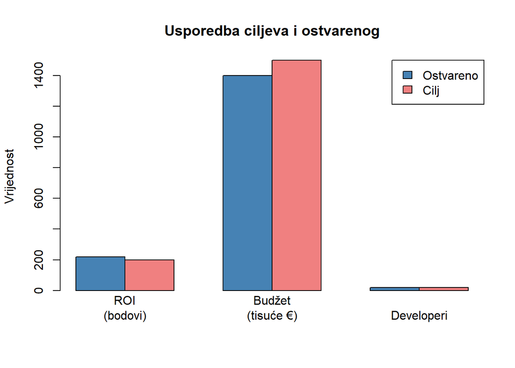

```r
# Graf ostvarenja ciljeva
ciljevi_postignuto <- c(bodovi_ostvareno, troskovi, zauzeto)
ciljevi_planirano <- c(cilj_roi, cilj_budzet, cilj_developeri)
nazivi_ciljeva <- c("ROI\n(bodovi)", "Budžet\n(tisuće €)", "Developeri")

barplot(rbind(ciljevi_postignuto, ciljevi_planirano),
        names.arg = nazivi_ciljeva,
        col = c("steelblue", "lightcoral"),
        main = "Usporedba ciljeva i ostvarenog",
        ylab = "Vrijednost",
        beside = TRUE,
        legend.text = c("Ostvareno", "Cilj"),
        args.legend = list(x = "topright"))
```

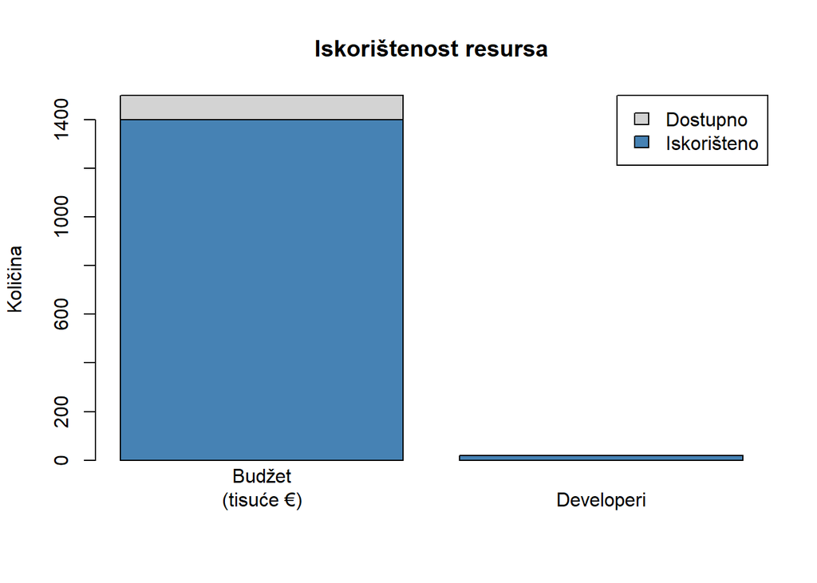

```r
# Graf iskorištenosti resursa
resursi <- c(troskovi, zauzeto)
maksimum <- c(1500, 20)
nazivi <- c("Budžet\n(tisuće €)", "Developeri")

barplot(rbind(resursi, maksimum - resursi),
        names.arg = nazivi,
        col = c("steelblue", "lightgray"),
        main = "Iskorištenost resursa",
        ylab = "Količina",
        legend.text = c("Iskorišteno", "Dostupno"),
        args.legend = list(x = "topright"))
```

### 3.3. Tumačenje dobivenih rješenja

Korištenjem pristupa ciljnog programiranja s prioritetima dobiveno je kompromisno rješenje koje najbolje balansira sve tri cilja.

**Odabrani projekti:**

**Analiza ostvarenja ciljeva:**

**Cilj 1 - ROI (prioritet 1):** Ostvareno je 220 bodova od ciljanih 200 bodova. Pozitivno odstupanje d1+ = 20 pokazuje da je najvažniji cilj ne samo postignut, već i premašen za 20 bodova. Negativno odstupanje d1- = 0, što znači da nismo ispod cilja. Ovo je odličan rezultat jer ROI ima najviši prioritet.

**Provjera ograničenja:**

P5 se ne može raditi uz P1, a P1 sam donosi više bodova (90 prema 30).

**Analiza:**

Svaki pokušaj poboljšanja jednog cilja bi pogoršao neki drugi cilj višeg prioriteta, što pokazuje da je pronađeno optimalno balansirano rješenje.

## 4. Zaključak

**Razlog za analizu:** Trebalo je pomoći direktoru da donese odluku koja balansira više konfliktnih ciljeva: postići dobar ROI, držati se unutar budžeta i maksimalno iskoristiti tim. Pristup s više ciljeva omogućio je način rješavanja ovog problema kroz jasno definiranje prioriteta.

Sva tri prioriteta su zadovoljena, što pokazuje da je pronađeno balansirano rješenje.